# R Notebook

## AMP GLO NEBuffer 4+ 2.1 Thawed Standard Curves for concentrations from 0.01uM to 0.625uM, including 0uM

### Conclusion

Low concentrations actually look decent on this batch too. 0 hr timepoint looks worse than 1 hr timepoint, as shown in DETECTR 040. Summing doesn’t seem to help. I would trust 0.15uM and above.

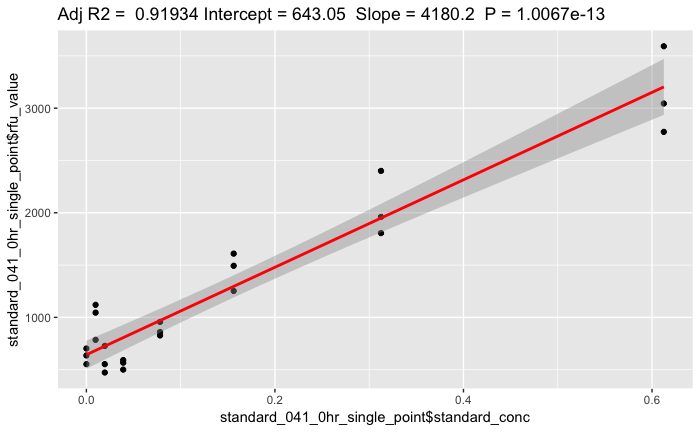

```r
DETECTR_041 <- read.csv("../tidy_data/DETECTR_041_kinetics_tidy_metadata.csv")
standard_041 <- subset(DETECTR_041, DETECTR_041$sample_set == "AMP_standard" & !(is.na(DETECTR_041$time)) & !(is.na(DETECTR_041$rfu_value)))
standard_041$standard_conc <- as.numeric(as.character(standard_041$standard_conc))
standard_041 = subset(standard_041,standard_conc<=0.625)
standard_041_0hr_single_point = subset(standard_041,time =="00:00:00")
standard_041_1hr_single_point = subset(standard_041,time =="00:50:00")
#standard_041_30min = sumBelowTime(standard_041,0,30,0)
standard_041_1hr = sumBelowTime(standard_041,0,50,0)
#standard_041_3hr = sumBelowTime(standard_041,3,0,0)
#standard_041_6hr = sumBelowTime(standard_041,6,0,0)
#standard_041_12hr = sumBelowTime(standard_041,12,0,0)
ggplotRegression(lm(standard_041_0hr_single_point$rfu_value~standard_041_0hr_single_point$standard_conc))
```

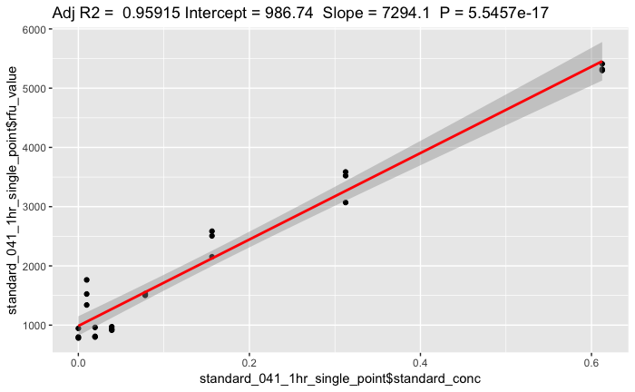

```r
ggplotRegression(lm(standard_041_1hr_single_point$rfu_value~standard_041_1hr_single_point$standard_conc))
```

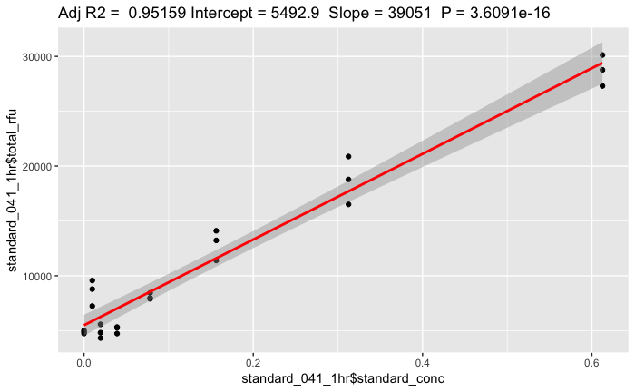

```r
#ggplotRegression(lm(standard_041_30min$total_rfu~standard_041_30min$standard_conc))
ggplotRegression(lm(standard_041_1hr$total_rfu~standard_041_1hr$standard_conc))
```

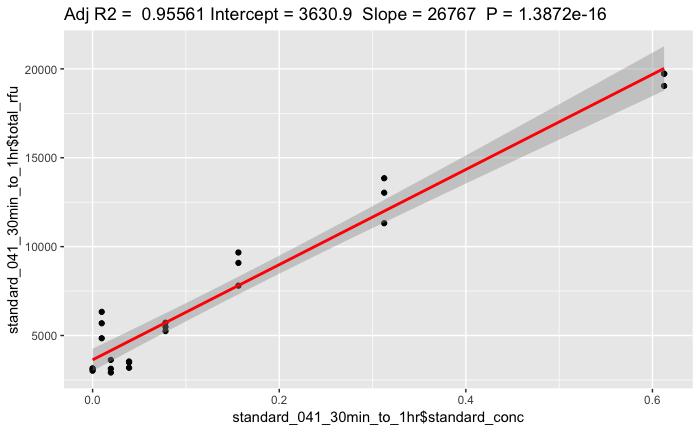

```r
#ggplotRegression(lm(standard_041_3hr$total_rfu~standard_041_3hr$standard_conc))
#ggplotRegression(lm(standard_041_6hr$total_rfu~standard_041_6hr$standard_conc))
#ggplotRegression(lm(standard_041_12hr$total_rfu~standard_041_12hr$standard_conc))
standard_041_30min_to_1hr = subset(standard_041, (hours <= 0 & minutes <= 50 & seconds <= 0) & (hours <= 0 & minutes >= 20 & seconds <= 0))
standard_041_30min_to_1hr = standard_041_30min_to_1hr %>% group_by(standard_conc, replicate) %>% summarize (total_rfu=sum(rfu_value))
ggplotRegression(lm(standard_041_30min_to_1hr$total_rfu~standard_041_30min_to_1hr$standard_conc))
```

### Conclusion

UMP standard curve seems to really benefit from summing over time. I would trust the 0.04uM point on the 1hr sum. Signal seems to degrade over time.

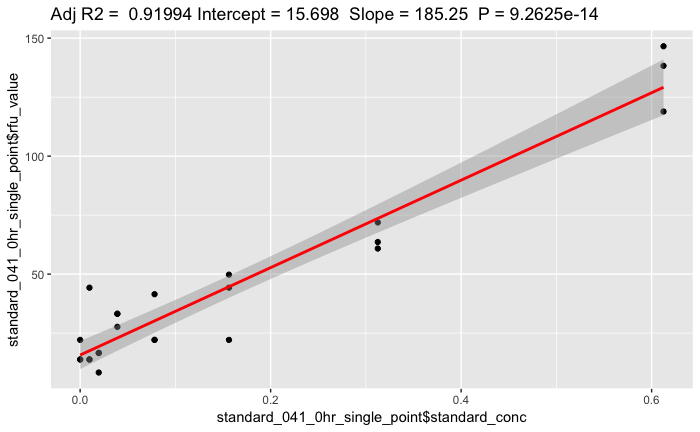

```r
DETECTR_041 <- read.csv("../tidy_data/DETECTR_041_kinetics_tidy_metadata.csv")
standard_041 <- subset(DETECTR_041, DETECTR_041$sample_set == "UMP_standard" & !(is.na(DETECTR_041$time)) & !(is.na(DETECTR_041$rfu_value)))
standard_041$standard_conc <- as.numeric(as.character(standard_041$standard_conc))
standard_041 = subset(standard_041,standard_conc<=0.625)
standard_041_0hr_single_point = subset(standard_041,time =="00:00:00")
standard_041_1hr_single_point = subset(standard_041,time =="00:50:00")
#standard_041_30min = sumBelowTime(standard_041,0,30,0)
standard_041_1hr = sumBelowTime(standard_041,0,50,0)
#standard_041_3hr = sumBelowTime(standard_041,3,0,0)
#standard_041_6hr = sumBelowTime(standard_041,6,0,0)
#standard_041_12hr = sumBelowTime(standard_041,12,0,0)
ggplotRegression(lm(standard_041_0hr_single_point$rfu_value~standard_041_0hr_single_point$standard_conc))
```

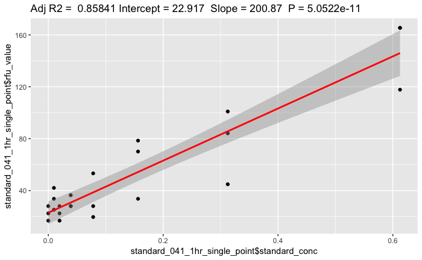

```r
ggplotRegression(lm(standard_041_1hr_single_point$rfu_value~standard_041_1hr_single_point$standard_conc))
```

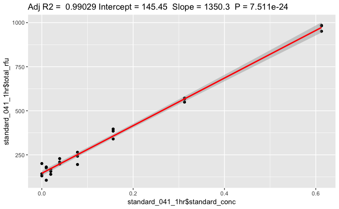

```r
#ggplotRegression(lm(standard_041_30min$total_rfu~standard_041_30min$standard_conc))
ggplotRegression(lm(standard_041_1hr$total_rfu~standard_041_1hr$standard_conc))
```

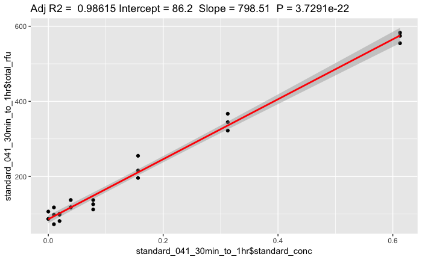

```r
#ggplotRegression(lm(standard_041_3hr$total_rfu~standard_041_3hr$standard_conc))
#ggplotRegression(lm(standard_041_6hr$total_rfu~standard_041_6hr$standard_conc))
#ggplotRegression(lm(standard_041_12hr$total_rfu~standard_041_12hr$standard_conc))
standard_041_30min_to_1hr = subset(standard_041, (hours <= 0 & minutes <= 50 & seconds <= 0) & (hours <= 0 & minutes >= 20 & seconds <= 0))
standard_041_30min_to_1hr = standard_041_30min_to_1hr %>% group_by(standard_conc, replicate) %>% summarize (total_rfu=sum(rfu_value))
ggplotRegression(lm(standard_041_30min_to_1hr$total_rfu~standard_041_30min_to_1hr$standard_conc))
```

## AMP 0uM standards in row below AMP standard curve starting at 10uM and going down to 0uM

The AMP standards were in rows A, C and E for this plate. I placed 0uM standards in rows B, D, and F.

### Conclusions

There seems to be a noticeable trend in higher values in the left columns, where the higher conc standards are. However, it is not completely outside of the expected variance. Some of the right column 0uM wells still reach fairly high values. We can conclude that there is probably a little crosstalk from the high concentration standards, but probably wouldn’t make a negative sample appear positive.

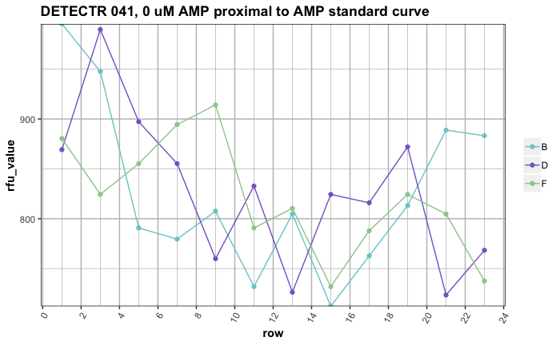

## Water in row below UMP standard curve starting at 10uM and going down to 0uM

The UMP standards were in rows H, J and L for this plate. I pulled the waters directly below them in rows I, K and M.

### Conclusions

There is no noticeable cross-talk from the UMP standards to the adjacent waters.

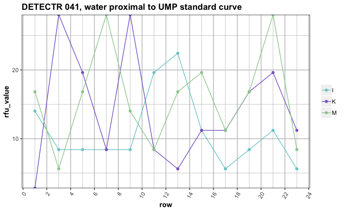

## Comparing proximal and distal AMP 0uM standards and proximal water wells

The AMP standards were in rows A, C and E for this plate. I placed 0uM AMP standards in rows B, D, and F. The UMP standards were in rows H, J and L for this plate. I pulled the waters directly below them in rows I, K and M. The distal 0uM AMP standards were in row N, O and P on the plate.

### Conclusions

Proximal 0uM AMP standards to the 10uM and 5uM have slightly higher signal than those in the distal category. However, majority of signal is coming from the reagent itself, which you can see by comparing to water wells.

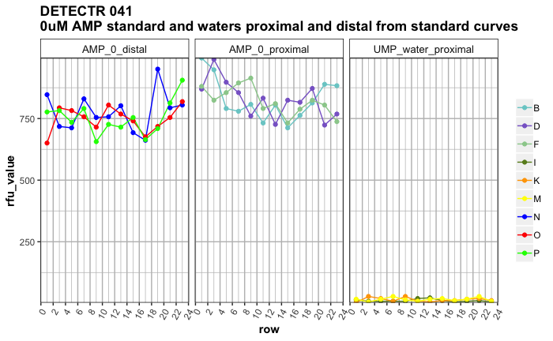

## Comparing all water wells on the plate

The AMP standards were in rows A, C and E for this plate. I placed 0uM AMP standards in rows B, D, and F. The UMP standards were in rows H, J and L for this plate. I pulled the waters directly below them in rows I, K and M. The distal 0uM AMP standards were in row N, O and P on the plate.

### Conclusions

Waters next to the 10uM and 5uM have higher signal than those farther away. None of that signal is higher than a 0 uM AMP standard (~750). There is more cross-talk in directly adjacent cells than in diagonal wells, and if the well is near more than 1 high signal well.

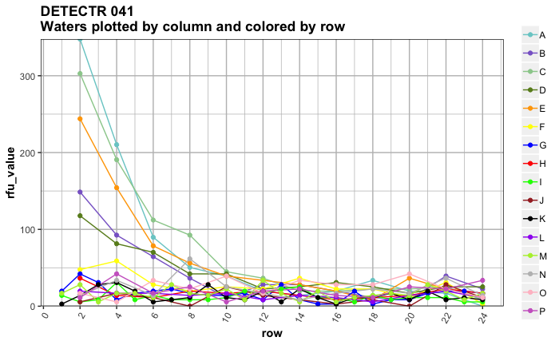